# Tree Visualization

Guangchuang Yu and Tommy Tsan-Yuk Lam School of Basic Medical Sciences, Southern Medical University

2018-11-29

To view a phylogenetic tree, we first need to parse the tree file into *R*. The ggtree (Yu et al. 2017) package supports many file formats via the treeio package, including output files of commonly used software packages in evolutionary biology. For more details, plase refer to the [treeio vignette](https://bioconductor.org/packages/devel/bioc/vignettes/treeio/inst/doc/Importer.html).

```r
library("treeio")
library("ggtree")

nwk <- system.file("extdata", "sample.nwk", package="treeio")
tree <- read.tree(nwk)
```

# Viewing a phylogenetic tree with *ggtree*

The ggtree package extends ggplot2 (Wickham 2009) package to support viewing phylogenetic tree. It implements `geom_tree` layer for displaying phylogenetic tree, as shown below:

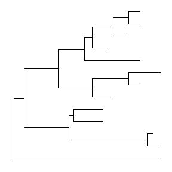

```r
ggplot(tree, aes(x, y)) + geom_tree() + theme_tree()
```

The function, `ggtree`, was implemented as a short cut to visualize a tree, and it works exactly the same as shown above.

ggtree takes all the advantages of ggplot2. For example, we can change the color, size and type of the lines as we do with ggplot2.

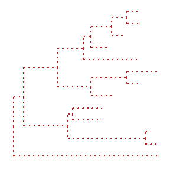

```r
ggtree(tree, color="firebrick", size=1, linetype="dotted")
```

By default, the tree is viewed in ladderize form, user can set the parameter *ladderize = FALSE* to disable it.

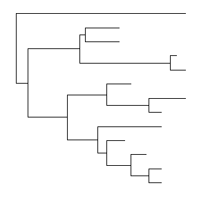

```r
ggtree(tree, ladderize=FALSE)
```

The *branch.length* is used to scale the edge, user can set the parameter *branch.length = “none”* to only view the tree topology (cladogram) or other numerical variable to scale the tree (*e.g.* *d<sub>N</sub>/d<sub>S</sub>*, see also in Tree Annotation vignette).

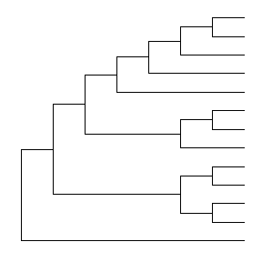

```r
ggtree(tree, branch.length="none")
```

# Layout

Currently, ggtree supports several layouts, including:

- rectangular (by default)
- slanted
- circular
- fan

for *phylogram* (by default) and *cladogram* if user explicitly setting *branch.length=‘none’*. Unrooted (equal angle and daylight methods), time-scaled and 2-dimensional layouts are also supported.

## Phylogram and Cladogram

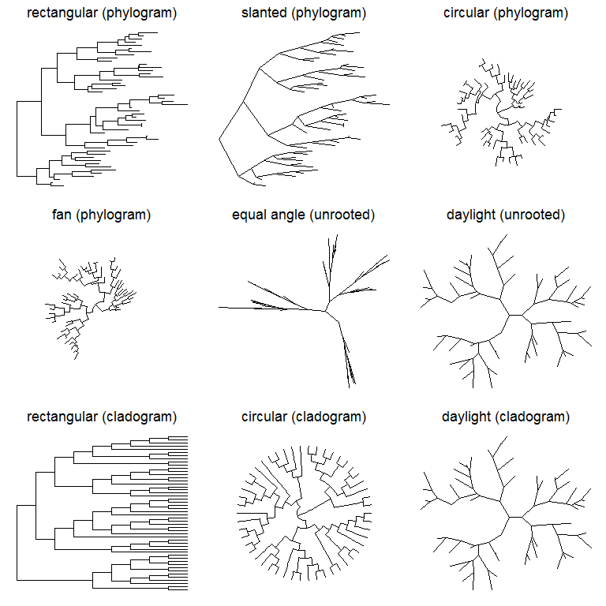

```r
library(ggtree)
set.seed(2017-02-16)
tr <- rtree(50)
ggtree(tr)
ggtree(tr, layout="slanted")
ggtree(tr, layout="circular")
ggtree(tr, layout="fan", open.angle=120)
ggtree(tr, layout="equal_angle")
ggtree(tr, layout="daylight")
ggtree(tr, branch.length='none')
ggtree(tr, branch.length='none', layout='circular')
ggtree(tr, layout="daylight", branch.length='none')
```

There are also other possible layouts that can be drawn by modifying scales/coordination, for examples, [reverse label of time scale](https://github.com/GuangchuangYu/ggtree/issues/87), [repropotion circular/fan tree](https://groups.google.com/d/msgid/bioc-ggtree/6db25ec7-ffb1-4776-bfe4-4a1ba239c8e8%40googlegroups.com), *etc.*.

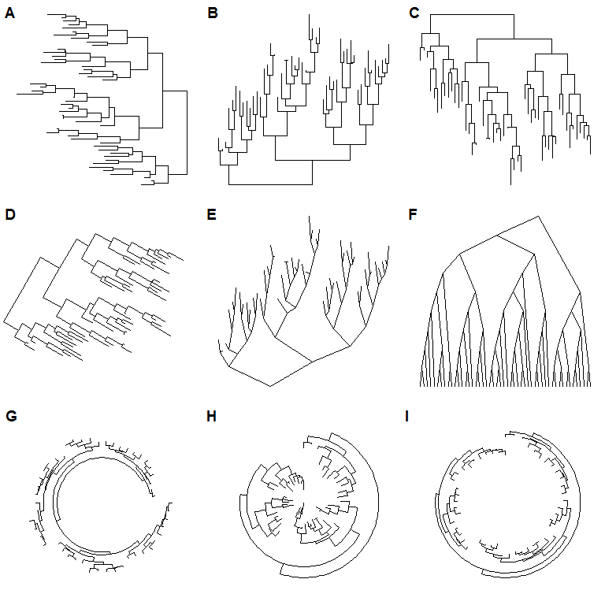

```r
ggtree(tr) + scale_x_reverse()
ggtree(tr) + coord_flip()
ggtree(tr) + scale_x_reverse() + coord_flip()
print(ggtree(tr), newpage=TRUE, vp=grid::viewport(angle=-30, width=.9, height=.9))
ggtree(tr, layout='slanted') + coord_flip()
ggtree(tr, layout='slanted', branch.length='none') +
    coord_flip() + scale_y_reverse() +scale_x_reverse()
ggtree(tr, layout='circular') + xlim(-10, NA)
ggtree(tr) + scale_x_reverse() + coord_polar(theta='y')
ggtree(tr) + scale_x_reverse(limits=c(10, 0)) + coord_polar(theta='y')
```

## Time-scaled tree

A phylogenetic tree can be scaled by time (time-scaled tree) by specifying the parameter, *mrsd* (most recent sampling date).

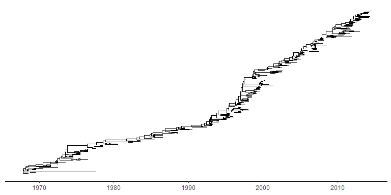

```r
tree2d <- read.beast(system.file("extdata", "twoD.tree", package="treeio"))
ggtree(tree2d, mrsd="2014-05-01") + theme_tree2()
```

## Two dimensional tree

ggtree implemented two dimensional tree. It accepts parameter *yscale* to scale the y-axis based on the selected tree attribute. The attribute should be numerical variable. If it is *character*/*category* variable, user should provides a name vector of mapping the variable to numeric by passing it to parameter *yscale_mapping*.

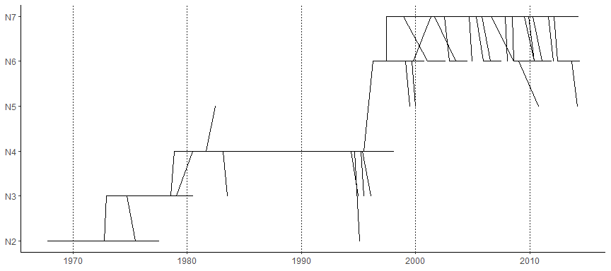

```r
ggtree(tree2d, mrsd="2014-05-01",
       yscale="NGS", yscale_mapping=c(N2=2, N3=3, N4=4, N5=5, N6=6, N7=7)) +
           theme_classic() + theme(axis.line.x=element_line(), axis.line.y=element_line()) +
               theme(panel.grid.major.x=element_line(color="grey20", linetype="dotted", size=.3),
                     panel.grid.major.y=element_blank()) +
                         scale_y_continuous(labels=paste0("N", 2:7))
```

In this example, the figure demonstrates the quantity of *y* increase along the trunk. User can highlight the trunk with different line size or color using the functions described in Tree Manipulation vignette.

# Displaying tree scale (evolution distance)

To show tree scale, user can use `geom_treescale()` layer.

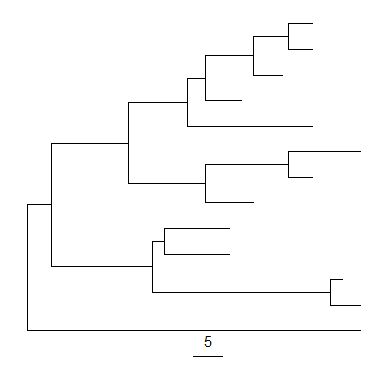

```r
ggtree(tree) + geom_treescale()
```

`geom_treescale()` supports the following parameters:

- *x* and *y* for tree scale position
- *width* for the length of the tree scale
- *fontsize* for the size of the text
- *linesize* for the size of the line
- *offset* for relative position of the line and the text
- *color* for color of the tree scale

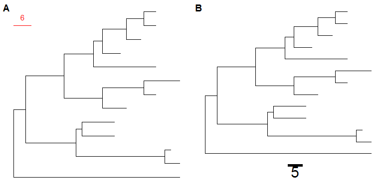

```r
ggtree(tree) + geom_treescale(x=0, y=12, width=6, color='red')
ggtree(tree) + geom_treescale(fontsize=8, linesize=2, offset=-1)
```

We can also use `theme_tree2()` to display the tree scale by adding *x axis*.

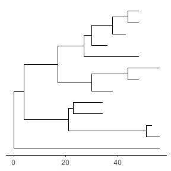

```r
ggtree(tree) + theme_tree2()
```

Tree scale is not restricted to evolution distance, ggtree can re-scale the tree with other numerical variable. More details can be found in the Tree Annotation vignette.

# Displaying nodes/tips

Showing all the internal nodes and tips in the tree can be done by adding a layer of points using `geom_nodepoint`, `geom_tippoint` or `geom_point`.

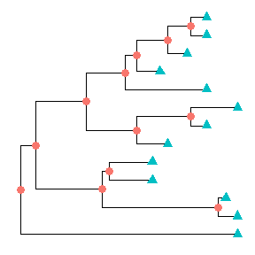

```r
ggtree(tree) + geom_point(aes(shape=isTip, color=isTip), size=3)
```

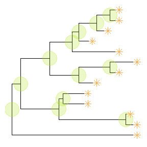

```r
p <- ggtree(tree) + geom_nodepoint(color="#b5e521", alpha=1/4, size=10)
p + geom_tippoint(color="#FDAC4F", shape=8, size=3)
```

## Displaying labels

Users can use `geom_text` or `geom_label` to display the node (if available) and tip labels simultaneously or `geom_tiplab` to only display tip labels:

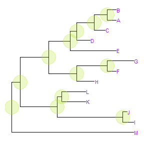

```r
p + geom_tiplab(size=3, color="purple")
```

`geom_tiplab` not only supports using *text* or *label* geom to display labels, it also supports *image* geom to label tip with image files. A corresponding geom, `geom_nodelab` is also provided for displaying node labels. For details of label nodes with images, please refer to the vignette, [Annotating phylogenetic tree with images](https://guangchuangyu.github.io/software/ggtree/vignettes/ggtree-ggimage.html).

For *circular* and *unrooted* layout, ggtree supports rotating node labels according to the angles of the branches.

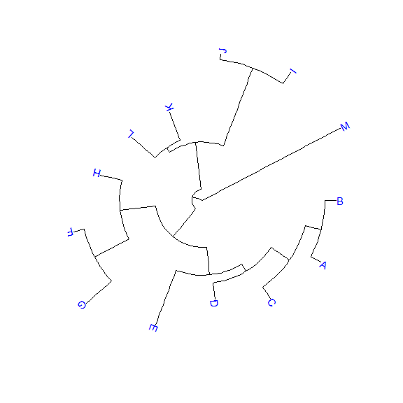

```r
ggtree(tree, layout="circular") + geom_tiplab(aes(angle=angle), color='blue')
```

To make it more readable for human eye, ggtree provides a `geom_tiplab2` for `circular` layout (see post [1](https://groups.google.com/forum/?utm_medium=email&utm_source=footer#!topic/bioc-ggtree/o35PV3iHO-0) and [2](https://groups.google.com/forum/#!topic/bioc-ggtree/p42R5l8J-14)).

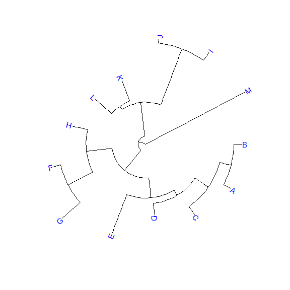

```r
ggtree(tree, layout="circular") + geom_tiplab2(color='blue')
```

By default, the positions are based on the node positions, we can change them to based on the middle of the branch/edge.

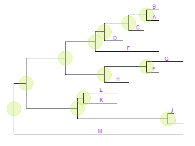

```r
p + geom_tiplab(aes(x=branch), size=3, color="purple", vjust=-0.3)
```

Based on the middle of branch is very useful when annotating transition from parent node to child node.

# Update tree view with a new tree

In previous example, we have a *`p`* object that stored the tree viewing of 13 tips and internal nodes highlighted with specific colored big dots. If users want to apply this pattern (we can imaging a more complex one) to a new tree, you don’t need to build the tree step by step. `ggtree` provides an operator, *`%<%`*, for applying the visualization pattern to a new tree.

For example, the pattern in the *`p`* object will be applied to a new tree with 50 tips as shown below:

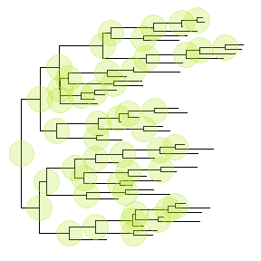

```r
p %<% rtree(50)
```

# Theme

`theme_tree()` defined a totally blank canvas, while *`theme_tree2()`* adds phylogenetic distance (via x-axis). These two themes all accept a parameter of *`bgcolor`* that defined the background color. Users can pass any [theme components](http://ggplot2.tidyverse.org/reference/theme.html) to the `theme_tree()` function to modify them.

[figure not shown]

```r
ggtree(rtree(30), color="red") + theme_tree("steelblue")
ggtree(rtree(20), color="white") + theme_tree("black")
```

# Visualize a list of trees

`ggtree` supports `multiPhylo` object and a list of trees can be viewed simultaneously.

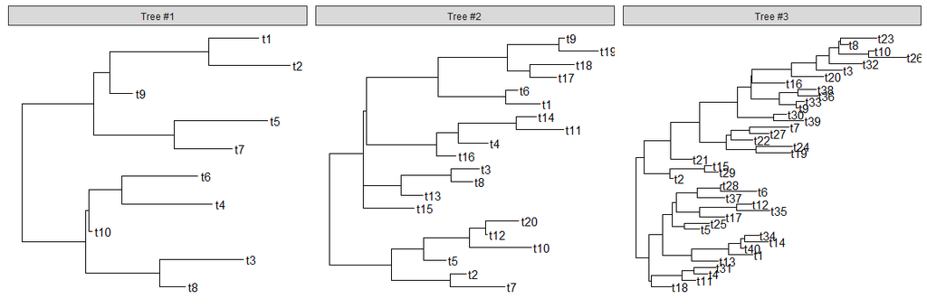

```r
trees <- lapply(c(10, 20, 40), rtree)
class(trees) <- "multiPhylo"
ggtree(trees) + facet_wrap(~.id, scale="free") + geom_tiplab()
```

One hundred bootstrap trees can also be view simultaneously.

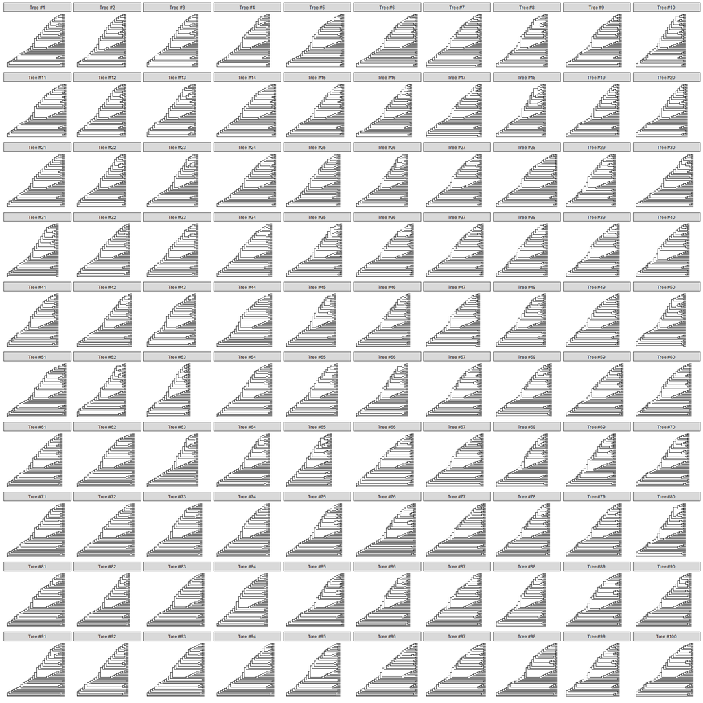

```r
btrees <- read.tree(system.file("extdata/RAxML", "RAxML_bootstrap.H3", package="treeio"))
ggtree(btrees) + facet_wrap(~.id, ncol=10)
```

Another way to view the bootstrap trees is to merge them together to form a density tree. We can add a layer of the best tree on the top of the density tree.

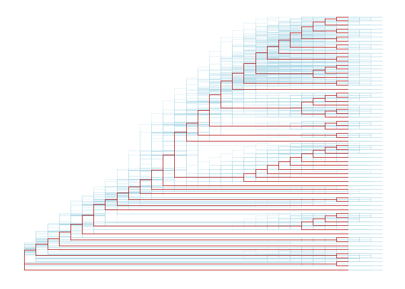

```r
p <- ggtree(btrees, layout="rectangular", color="lightblue", alpha=.3)

best_tree <- read.tree(system.file("extdata/RAxML", "RAxML_bipartitionsBranchLabels.H3", package="treeio"))
df <- fortify(best_tree, branch.length='none')
p+geom_tree(data=df, color='firebrick')
```

# Rescale tree

Most of the phylogenetic trees are scaled by evolutionary distance (substitution/site). In `ggtree`, users can re-scale a phylogenetic tree by any numerical variable inferred by evolutionary analysis (e.g. *dN/dS*).

```r
library("treeio")
beast_file <- system.file("examples/MCC_FluA_H3.tree", package="ggtree")
beast_tree <- read.beast(beast_file)
beast_tree
```

```
## 'treedata' S4 object that stored information of
##  'C:/Users/biocbuild/bbs-3.8-bioc/tmpdir/RtmpIZJlMK/Rinst19070567f40/ggtree/examples/MCC_FluA_H3.tree'.
##
## ...@ phylo:
## Phylogenetic tree with 76 tips and 75 internal nodes.
##
## Tip labels:
##  A/Hokkaido/30-1-a/2013, A/New_York/334/2004, A/New_York/463/2005, A/New_York/452/1999, A/New_York/238/2005, A/New_York/523/1998, ...
##
## Rooted; includes branch lengths.
##
## with the following features available:
##  'height',   'height_0.95_HPD',  'height_median',    'height_range', 'length',
##  'length_0.95_HPD',  'length_median',    'length_range', 'posterior',    'rate',
##  'rate_0.95_HPD',    'rate_median',  'rate_range'.
```

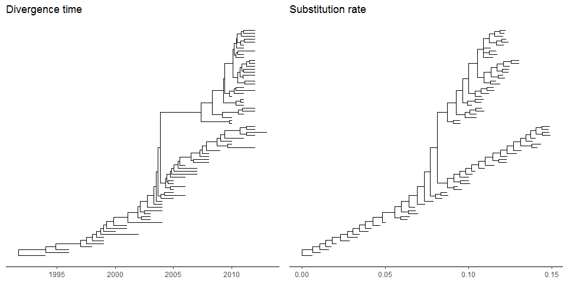

```r
p1 <- ggtree(beast_tree, mrsd='2013-01-01') + theme_tree2() +
    ggtitle("Divergence time")
p2 <- ggtree(beast_tree, branch.length='rate') + theme_tree2() +
    ggtitle("Substitution rate")

library(cowplot)
plot_grid(p1, p2, ncol=2)
```

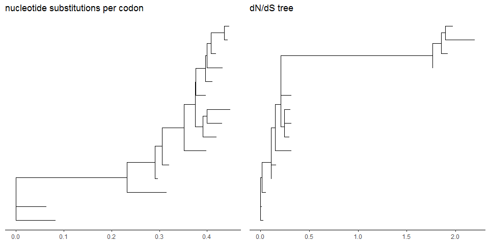

```r
mlcfile <- system.file("extdata/PAML_Codeml", "mlc", package="treeio")
mlc_tree <- read.codeml_mlc(mlcfile)
p1 <- ggtree(mlc_tree) + theme_tree2() +
    ggtitle("nucleotide substitutions per codon")
p2 <- ggtree(mlc_tree, branch.length='dN_vs_dS') + theme_tree2() +
    ggtitle("dN/dS tree")
plot_grid(p1, p2, ncol=2)
```

In addition to specify `branch.length` in tree visualization, users can change branch length stored in tree object by using `rescale_tree` function.

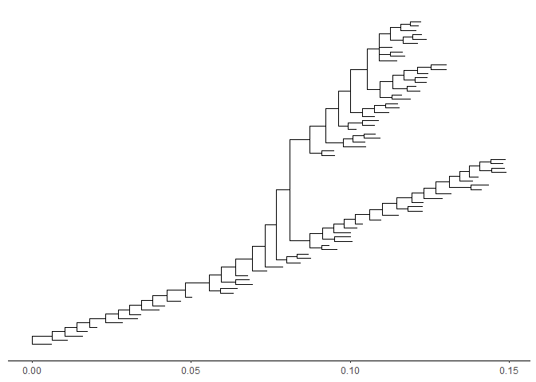

```r
beast_tree2 <- rescale_tree(beast_tree, branch.length='rate')
ggtree(beast_tree2) + theme_tree2()
```

# Zoom on a portion of tree

`ggtree` provides *`gzoom`* function that similar to *`zoom`* function provided in `ape`. This function plots simultaneously a whole phylogenetic tree and a portion of it. It aims at exploring very large trees.

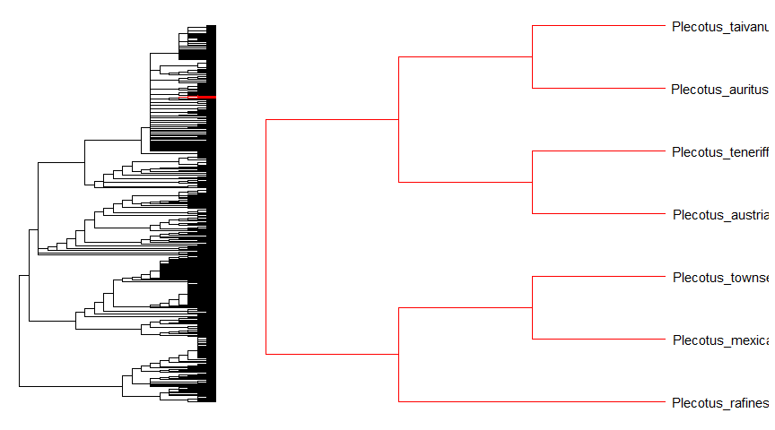

```r
library("ape")
data(chiroptera)
library("ggtree")
gzoom(chiroptera, grep("Plecotus", chiroptera$tip.label))
```

Zoom in selected clade of a tree that was already annotated with `ggtree` is also supported.

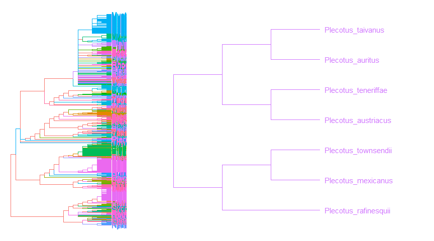

```r
groupInfo <- split(chiroptera$tip.label, gsub("_\\w+", "", chiroptera$tip.label))
chiroptera <- groupOTU(chiroptera, groupInfo)
p <- ggtree(chiroptera, aes(color=group)) + geom_tiplab() + xlim(NA, 23)
gzoom(p, grep("Plecotus", chiroptera$tip.label), xmax_adjust=2)
```

# Color tree

In `ggtree`, coloring phylogenetic tree is easy, by using `aes(color=VAR)` to map the color of tree based on a specific variable (numeric and category are both supported).

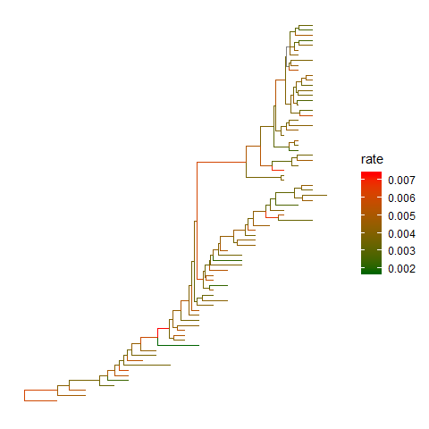

```r
ggtree(beast_tree, aes(color=rate)) +
    scale_color_continuous(low='darkgreen', high='red') +
    theme(legend.position="right")
```

User can use any feature (if available), including clade posterior and *dN/dS* *etc.*, to scale the color of the tree.

# References

Wickham, Hadley. 2009. *Ggplot2: Elegant Graphics for Data Analysis*. 1st ed. Springer.

Yu, Guangchuang, David K. Smith, Huachen Zhu, Yi Guan, and Tommy Tsan-Yuk Lam. 2017. “Ggtree: An R Package for Visualization and Annotation of Phylogenetic Trees with Their Covariates and Other Associated Data.” *Methods in Ecology and Evolution* 8 (1):28–36. https://doi.org/10.1111/2041-210X.12628.